# Mapping the Transnational Public Sphere in modern China (1)

Structural Topic Modeling of the *Shenbao

Cécile Armand

2022-09-21

Abstract

This is the companion documentation to a conference paper initially entitled “Local elites with global outreach: A bilingual topic modeling of the Shanghai press (1919-49)” given at the ESSCS conference “New Foundations in Chinese Digital History” held at Aix-Marseille University, 24-25 June 2022. This paper aims to map the formation of a transnational public sphere in republican China using a bilingual structural topic modeling approach. This document focuses on the Chinese-language corpus built from the newspaper *Shenbao*.

# Research context

This paper seeks to investigate the formation of a transnational public sphere in republican China, through the joint empirical study of two key institutions – a non-state transnational organization, the Rotary Club, and its representations in the Shanghai press, which has long been considered as a key medium for shaping and disseminating information in modern China (Rankin, 1990; Huang, 1993; Wakeman, 1993; Wagner, 2007). Previous research on the Chinese public sphere presents to main limitations. One the one hand, scholars have focused on theoretical discussions regarding the transferability of Western concepts in China, instead of examining its concrete manifestations in the press and how it was put in practice by social actors. On the other hand, scholars who have used the press as a source have essentially relied on the close reading of subjectively selected articles, without providing the possibility to contextualize their findings and to assess whether/to what extent the selected texts or passages were representative of larger trends.

Taking advantage of the massive, multilingual corpora recently made available in full text by the [ENP-China (Elites, Networks and Power in modern China) project](https://www.enpchina.eu/), this paper introduces a mixed-method approach based on topic modeling to enable a change of scale in the analysis of the historical press and to overcome certain limitations of manual reading.Topic modeling is a computational, statistical method aimed at automatically detecting hidden themes (topics) in large collections of unstructured texts, based on the co-occurrences of words in documents. In this paper, we rely on structural topic modeling (STM). STM is based on Latent Dirichlet Allocation (LDA), a probabilistic model that treats topics as mixtures of words and documents as mixtures of topics. This implies that words can belong to different topics, while topics can be represented in multiple documents with varying proportions. In addition, STM is able to incorporate document metadata such as the date of publication, which enables to analyze topical changes over time. More specifically, we will use the [stm R package](https://warin.ca/shiny/stm/) which includes several built-in functions designed to facilitate the exploration of topics, including various visualizations and statistical outputs.

The purpose of this research is twofold. Substantively, our key questions include: How did the Shanghai press reported on the Rotary Club? How did the organization mediate between elite/society, business/politics, localism/internationalism? What does this reveal about how the press itself functioned as a public sphere? How did this emerging public sphere change over time and vary across languages? Methodologically, we aim to design a reliable method for conducting a bilingual, dynamic topic modeling approach of the historical press. More specifically, we address three major challenges: (1) to identify topics across multiple languages (in this paper, English and Chinese), (2) to trace topical changes over time, and (3) to adapt topic modeling to the heterogeneity of newspaper content, particularly to brevity-style articles made up of short pieces of unrelated news.

In this document, we focus on the Chinese-language newspaper *Shenbao* (Chinese)[^1]. For the English-language press (ProQuest Collection of Chinese Newspapers), see the counterpart document. Our workflow follows four main steps. First, we build the corpus from the ENP-China textbase using the [HistText package](https://bookdown.enpchina.eu/rpackage/HistTextRManual.html). Second, we prepare the text data and build the topic models using the [stm package](https://www.structuraltopicmodel.com/). Next, we explore and label the topics using various visualizations and statistical measures. Finally, we analyze the effect of time on topic prevalence based on the date of publication.

Note: The purpose of this document is to describe our workflow and to make our methodological choices more explicit, testable and replicable. Historical questions and interpretations are kept to the minimum. For a comprehensive literature review and detailed interpretation of the findings embedded in the final narrative, see to the companion research paper to be published in the [*Journal of Digital History* (JDH)](https://journalofdigitalhistory.org/en).

# Corpus building

Load packages

```r
library(histtext)
library(tidyverse)
```

We first search “扶輪社” (fulunshe) in the *Shenbao*. Since we are investigating a very specific organization with few possible homonyms and low degree of ambiguity, we can rely on simple keywords. We simply exclude the quasi-homonym “國學扶輪社” (guoxue fulunshe), which referred to a publishing enterprise established in the early 20th century with no connection with the Rotary Club. Additionally, we restricted the query to the period posterior to 1919, when the first Rotary Club in China was established in Shanghai:

```r
rotaryzh_doc <- search_documents_ex('"扶輪社" NOT "國學扶輪社"', corpus="shunpao", dates="[1919 TO 1947]")
head(rotaryzh_doc)
```

| DocId | Date | Title | Source |
| --- | --- | --- | --- |
| SPSP194704140406 | 19470414 | 扶輪社年會閉幕 | shunpao |
| SPSP193011141210 | 19301114 | 扶輪社奬品待領 | shunpao |
| SPSP193001161619 | 19300116 | 扶輪社今午聚餐 | shunpao |
| SPSP193010291607 | 19301029 | 扶輪社 | shunpao |
| SPSP193301230735 | 19330123 | 濟扶輪社註册紀念 | shunpao |
| SPSP192902151513 | 19290215 | 扶輪社昨午聚餐會 | shunpao |

When we retrieved the full text of the documents (not done here), we realized that the results contained many articles in which the Rotary Club was just mentioned in passing, amidst unrelated pieces of news. Using the entire document as a text unit would only reflect the messy structure of these texts. In order to alleviate the issue, we propose to apply topic modeling on finer segments of text instead of the entire document.

```r
view_document("SPSP193602290401", "shunpao", query = '"扶輪社"')
```

## Retrieve concordance

Instead of retrieving entire documents, therefore, we will retrieve finer strings of characters using the “concordance” function included in the histtext package. This function returns the queried terms in their context. The main challenge at this stage is to define the right context size. After a careful examination of a sample of articles, we decided to set the threshold at 100 characters to minimize the risk of overlap in cases when articles contain several occurrences of the queried terms:

```r
rotaryzh_conc100 <- search_concordance_ex('"扶輪社" NOT "國學扶輪社"',
                                          context = 100, corpus="shunpao",
                                          dates="[1919 TO 1947]")

head(rotaryzh_conc100)
```

| DocId | Date | Title | Source | Before | Matched | After |
| --- | --- | --- | --- | --- | --- | --- |
| SPSP194704140406 | 19470414 | 扶輪社年會閉幕 | shunpao | 國際 | 扶輪社 | 第九十七區域年會昨日已爲最後一日，上午在美國敎堂舉行禮拜，下午在永安公司總經理郭禮安私邸舉行園遊會， |
| SPSP194704140406 | 19470414 | 扶輪社年會閉幕 | shunpao | 一日，上午在美國敎堂舉行禮拜，下午在永安公司總經理郭禮安私邸舉行園遊會，中外社友全體參加，盛况空前。 | 扶輪社 | 此次年會爲期三”，各地社友來滬參加者達百餘人，對於擴大扶輪社節圍及增進國際友誼，巳有詳細討論。 |
| SPSP194704140406 | 19470414 | 扶輪社年會閉幕 | shunpao | 舉行園遊會，中外社友全體參加，盛况空前。扶輪社此次年會爲期三”，各地社友來滬參加者達百餘人，對於擴大 | 扶輪社 | 節圍及增進國際友誼，巳有詳細討論。 |
| SPSP194704140406 | 19470414 | 扶輪社年會閉幕 | shunpao |  | 扶輪社 | 年會閉幕 |
| SPSP193011141210 | 19301114 | 扶輪社奬品待領 | shunpao | 前 | 扶輪社 | 爲俄意義務學校籌欵事曾在大華飯店舉行跳舞大會並舉行抽彩一種惟購票抽得彩品而迄今尙未持票領奬者尙有八十 |
| SPSP193011141210 | 19301114 | 扶輪社奬品待領 | shunpao | 學校籌欵事曾在大華飯店舉行跳舞大會並舉行抽彩一種惟購票抽得彩品而迄今尙未持票領奬者尙有八十餘號之多茲 | 扶輪社 | 限於六月二十四日以前待領逾期未領者槪行出售以價捐助俄童義務學校藉充校欵領奬處爲南京路五十號扶輪社事務 |

The concordance table contains seven columns, including the unique identifier of the document (DocId), the date of publication, the title of the article (Title), the name of the periodical (Source), the queried terms (Matched), and the terms preceding (Before) and following (After) the key words.

We can first count the number of occurrences per article:

```r
rotaryzh_conc100 <- rotaryzh_conc100 %>% group_by(DocId) %>% add_tally()

rotaryzh_conc100 %>% arrange(desc(n))
```

| DocId | Date | Title | Source | Before | Matched | After | n |
| --- | --- | --- | --- | --- | --- | --- | --- |
| SPSP193102061001 | 19310206 | 結賬期内莊票概出即期 錢莊爲便利商業流通欵項計、向有十天期之遠期莊票、以代現欵、凡商貨授受、均作現欵使用、現在錢莊正值結束十九年度賬略時期、苟再出用遠期莊票、勢須與二十年度營業相混合、爲劃清界限起見、曾經委員會議决、凡二月十五日以後、各商號欲出莊票、概以即期爲限、不出遠期莊票、俟逾此結賬時期後、 | shunpao | 未遷入、嗣經納稅華人會及華董杜君出任調停、雙方均圓 解决、公董局已於昨日通知各攤基菜販、定於明日本埠 | 扶輪社 | 、昨日舉行盛大熱烈之聚餐會、席間由該會會長介紹萬國扶輪社特派員大衛生氏演說、氏首致謝忱、略謂、得在中 | 22 |
| SPSP193102061001 | 19310206 | 結賬期内莊票概出即期 錢莊爲便利商業流通欵項計、向有十天期之遠期莊票、以代現欵、凡商貨授受、均作現欵使用、現在錢莊正值結束十九年度賬略時期、苟再出用遠期莊票、勢須與二十年度營業相混合、爲劃清界限起見、曾經委員會議决、凡二月十五日以後、各商號欲出莊票、概以即期爲限、不出遠期莊票、俟逾此結賬時期後、 | shunpao | 、公董局已於昨日通知各攤基菜販、定於明日本埠扶輪社、昨日舉行盛大熱烈之聚餐會、席間由該會會長介紹萬國 | 扶輪社 | 特派員大衛生氏演說、氏首致謝忱、略謂、得在中國首創且會員國籍最多之扶輪社中演說、殊覺榮幸、扶輪社之組 | 22 |
| SPSP193102061001 | 19310206 | 結賬期内莊票概出即期 錢莊爲便利商業流通欵項計、向有十天期之遠期莊票、以代現欵、凡商貨授受、均作現欵使用、現在錢莊正值結束十九年度賬略時期、苟再出用遠期莊票、勢須與二十年度營業相混合、爲劃清界限起見、曾經委員會議决、凡二月十五日以後、各商號欲出莊票、概以即期爲限、不出遠期莊票、俟逾此結賬時期後、 | shunpao | 餐會、席間由該會會長介紹萬國扶輪社特派員大衛生氏演說、氏首致謝忱、略謂、得在中國首創且會員國籍最多之 | 扶輪社 | 中演說、殊覺榮幸、扶輪社之組織遍於世界、且皆呈長足之進展、而成續 著者、端推小吕宋·上海·天津·北平 | 22 |
| SPSP193102061001 | 19310206 | 結賬期内莊票概出即期 錢莊爲便利商業流通欵項計、向有十天期之遠期莊票、以代現欵、凡商貨授受、均作現欵使用、現在錢莊正值結束十九年度賬略時期、苟再出用遠期莊票、勢須與二十年度營業相混合、爲劃清界限起見、曾經委員會議决、凡二月十五日以後、各商號欲出莊票、概以即期爲限、不出遠期莊票、俟逾此結賬時期後、 | shunpao | 萬國扶輪社特派員大衛生氏演說、氏首致謝忱、略謂、得在中國首創且會員國籍最多之扶輪社中演說、殊覺榮幸、 | 扶輪社 | 之組織遍於世界、且皆呈長足之進展、而成續 著者、端推小吕宋·上海·天津·北平·大連·遼甯·哈爾濱·等 | 22 |
| SPSP193102061001 | 19310206 | 結賬期内莊票概出即期 錢莊爲便利商業流通欵項計、向有十天期之遠期莊票、以代現欵、凡商貨授受、均作現欵使用、現在錢莊正值結束十九年度賬略時期、苟再出用遠期莊票、勢須與二十年度營業相混合、爲劃清界限起見、曾經委員會議决、凡二月十五日以後、各商號欲出莊票、概以即期爲限、不出遠期莊票、俟逾此結賬時期後、 | shunpao | 進展、而成續 著者、端推小吕宋·上海·天津·北平·大連·遼甯·哈爾濱·等處所設立者、餘如智利國境内之 | 扶輪社 | 、其首創者亦僅於四年前正式成立今則已逾四十處若捷哥斯拉夫境内、三年前方有此組織、今則成立者已二十五處 | 22 |
| SPSP193102061001 | 19310206 | 結賬期内莊票概出即期 錢莊爲便利商業流通欵項計、向有十天期之遠期莊票、以代現欵、凡商貨授受、均作現欵使用、現在錢莊正值結束十九年度賬略時期、苟再出用遠期莊票、勢須與二十年度營業相混合、爲劃清界限起見、曾經委員會議决、凡二月十五日以後、各商號欲出莊票、概以即期爲限、不出遠期莊票、俟逾此結賬時期後、 | shunpao | 亦僅於四年前正式成立今則已逾四十處若捷哥斯拉夫境内、三年前方有此組織、今則成立者已二十五處、英國共有 | 扶輪社 | 三百五十處、僅倫敦一埠、已有五十五所一綜計目今扶輪社總數、當在三千二百處以上、社員十五萬四千人、國籍 | 22 |
| SPSP193102061001 | 19310206 | 結賬期内莊票概出即期 錢莊爲便利商業流通欵項計、向有十天期之遠期莊票、以代現欵、凡商貨授受、均作現欵使用、現在錢莊正值結束十九年度賬略時期、苟再出用遠期莊票、勢須與二十年度營業相混合、爲劃清界限起見、曾經委員會議决、凡二月十五日以後、各商號欲出莊票、概以即期爲限、不出遠期莊票、俟逾此結賬時期後、 | shunpao | 三年前方有此組織、今則成立者已二十五處、英國共有扶輪社三百五十處、僅倫敦一埠、已有五十五所一綜計目今 | 扶輪社 | 總數、當在三千二百處以上、社員十五萬四千人、國籍七十國、又坎拿大境内、凡有居民二千人以上之城市、均有 | 22 |
| SPSP193102061001 | 19310206 | 結賬期内莊票概出即期 錢莊爲便利商業流通欵項計、向有十天期之遠期莊票、以代現欵、凡商貨授受、均作現欵使用、現在錢莊正值結束十九年度賬略時期、苟再出用遠期莊票、勢須與二十年度營業相混合、爲劃清界限起見、曾經委員會議决、凡二月十五日以後、各商號欲出莊票、概以即期爲限、不出遠期莊票、俟逾此結賬時期後、 | shunpao | 總數、當在三千二百處以上、社員十五萬四千人、國籍七十國、又坎拿大境内、凡有居民二千人以上之城市、均有 | 扶輪社 | 之組設、計其總數、蓋逾一百十所、氏復謂、扶輪社之組織、苟非自有其眞價值者、則此世界各國優秀份子十五萬 | 22 |
| SPSP193102061001 | 19310206 | 結賬期内莊票概出即期 錢莊爲便利商業流通欵項計、向有十天期之遠期莊票、以代現欵、凡商貨授受、均作現欵使用、現在錢莊正值結束十九年度賬略時期、苟再出用遠期莊票、勢須與二十年度營業相混合、爲劃清界限起見、曾經委員會議决、凡二月十五日以後、各商號欲出莊票、概以即期爲限、不出遠期莊票、俟逾此結賬時期後、 | shunpao | 籍七十國、又坎拿大境内、凡有居民二千人以上之城市、均有扶輪社之組設、計其總數、蓋逾一百十所、氏復謂、 | 扶輪社 | 之組織、苟非自有其眞價值者、則此世界各國優秀份子十五萬四千人、當不克使其加入、現歐洲各大國、均各有扶 | 22 |
| SPSP193102061001 | 19310206 | 結賬期内莊票概出即期 錢莊爲便利商業流通欵項計、向有十天期之遠期莊票、以代現欵、凡商貨授受、均作現欵使用、現在錢莊正值結束十九年度賬略時期、苟再出用遠期莊票、勢須與二十年度營業相混合、爲劃清界限起見、曾經委員會議决、凡二月十五日以後、各商號欲出莊票、概以即期爲限、不出遠期莊票、俟逾此結賬時期後、 | shunpao | 社之組織、苟非自有其眞價值者、則此世界各國優秀份子十五萬四千人、當不克使其加入、現歐洲各大國、均各有 | 扶輪社 | 之設立、南美北美亦皆進行甚力、中國北方及日本爪哇等處、且莫不有顯著進步、即此可知世界名大城市、固無不 | 22 |

[output cut: 702 more lines]

Next, we create a new variable for the merged text

```r
# First merge "before" and the "matched" term into a new "Text" variable
rotaryzh_conc100 <- rotaryzh_conc100 %>% mutate(Text = paste0(Before, Matched))
head(rotaryzh_conc100)
```

| DocId | Date | Title | Source | Before | Matched | After | n | Text |
| --- | --- | --- | --- | --- | --- | --- | --- | --- |
| SPSP194704140406 | 19470414 | 扶輪社年會閉幕 | shunpao | 國際 | 扶輪社 | 第九十七區域年會昨日已爲最後一日，上午在美國敎堂舉行禮拜，下午在永安公司總經理郭禮安私邸舉行園遊會， | 4 | 國際扶輪社 |
| SPSP194704140406 | 19470414 | 扶輪社年會閉幕 | shunpao | 一日，上午在美國敎堂舉行禮拜，下午在永安公司總經理郭禮安私邸舉行園遊會，中外社友全體參加，盛况空前。 | 扶輪社 | 此次年會爲期三”，各地社友來滬參加者達百餘人，對於擴大扶輪社節圍及增進國際友誼，巳有詳細討論。 | 4 | 一日，上午在美國敎堂舉行禮拜，下午在永安公司總經理郭禮安私邸舉行園遊會，中外社友全體參加，盛况空前。扶輪社 |
| SPSP194704140406 | 19470414 | 扶輪社年會閉幕 | shunpao | 舉行園遊會，中外社友全體參加，盛况空前。扶輪社此次年會爲期三”，各地社友來滬參加者達百餘人，對於擴大 | 扶輪社 | 節圍及增進國際友誼，巳有詳細討論。 | 4 | 舉行園遊會，中外社友全體參加，盛况空前。扶輪社此次年會爲期三”，各地社友來滬參加者達百餘人，對於擴大扶輪社 |
| SPSP194704140406 | 19470414 | 扶輪社年會閉幕 | shunpao |  | 扶輪社 | 年會閉幕 | 4 | 扶輪社 |
| SPSP193011141210 | 19301114 | 扶輪社奬品待領 | shunpao | 前 | 扶輪社 | 爲俄意義務學校籌欵事曾在大華飯店舉行跳舞大會並舉行抽彩一種惟購票抽得彩品而迄今尙未持票領奬者尙有八十 | 4 | 前扶輪社 |
| SPSP193011141210 | 19301114 | 扶輪社奬品待領 | shunpao | 學校籌欵事曾在大華飯店舉行跳舞大會並舉行抽彩一種惟購票抽得彩品而迄今尙未持票領奬者尙有八十餘號之多茲 | 扶輪社 | 限於六月二十四日以前待領逾期未領者槪行出售以價捐助俄童義務學校藉充校欵領奬處爲南京路五十號扶輪社事務 | 4 | 學校籌欵事曾在大華飯店舉行跳舞大會並舉行抽彩一種惟購票抽得彩品而迄今尙未持票領奬者尙有八十餘號之多茲扶輪社 |

```r
# Next, merge the text resulting from previous operation (Text) with "after"
rotaryzh_conc100 <- rotaryzh_conc100 %>% mutate(Text = paste0(Text, After))
head(rotaryzh_conc100)
```

| DocId | Date | Title | Source | Before | Matched | After | n | Text |
| --- | --- | --- | --- | --- | --- | --- | --- | --- |
| SPSP194704140406 | 19470414 | 扶輪社年會閉幕 | shunpao | 國際 | 扶輪社 | 第九十七區域年會昨日已爲最後一日，上午在美國敎堂舉行禮拜，下午在永安公司總經理郭禮安私邸舉行園遊會， | 4 | 國際扶輪社第九十七區域年會昨日已爲最後一日，上午在美國敎堂舉行禮拜，下午在永安公司總經理郭禮安私邸舉行園遊會， |
| SPSP194704140406 | 19470414 | 扶輪社年會閉幕 | shunpao | 一日，上午在美國敎堂舉行禮拜，下午在永安公司總經理郭禮安私邸舉行園遊會，中外社友全體參加，盛况空前。 | 扶輪社 | 此次年會爲期三”，各地社友來滬參加者達百餘人，對於擴大扶輪社節圍及增進國際友誼，巳有詳細討論。 | 4 | 一日，上午在美國敎堂舉行禮拜，下午在永安公司總經理郭禮安私邸舉行園遊會，中外社友全體參加，盛况空前。扶輪社此次年會爲期三”，各地社友來滬參加者達百餘人，對於擴大扶輪社節圍及增進國際友誼，巳有詳細討論。 |
| SPSP194704140406 | 19470414 | 扶輪社年會閉幕 | shunpao | 舉行園遊會，中外社友全體參加，盛况空前。扶輪社此次年會爲期三”，各地社友來滬參加者達百餘人，對於擴大 | 扶輪社 | 節圍及增進國際友誼，巳有詳細討論。 | 4 | 舉行園遊會，中外社友全體參加，盛况空前。扶輪社此次年會爲期三”，各地社友來滬參加者達百餘人，對於擴大扶輪社節圍及增進國際友誼，巳有詳細討論。 |
| SPSP194704140406 | 19470414 | 扶輪社年會閉幕 | shunpao |  | 扶輪社 | 年會閉幕 | 4 | 扶輪社年會閉幕 |
| SPSP193011141210 | 19301114 | 扶輪社奬品待領 | shunpao | 前 | 扶輪社 | 爲俄意義務學校籌欵事曾在大華飯店舉行跳舞大會並舉行抽彩一種惟購票抽得彩品而迄今尙未持票領奬者尙有八十 | 4 | 前扶輪社爲俄意義務學校籌欵事曾在大華飯店舉行跳舞大會並舉行抽彩一種惟購票抽得彩品而迄今尙未持票領奬者尙有八十 |
| SPSP193011141210 | 19301114 | 扶輪社奬品待領 | shunpao | 學校籌欵事曾在大華飯店舉行跳舞大會並舉行抽彩一種惟購票抽得彩品而迄今尙未持票領奬者尙有八十餘號之多茲 | 扶輪社 | 限於六月二十四日以前待領逾期未領者槪行出售以價捐助俄童義務學校藉充校欵領奬處爲南京路五十號扶輪社事務 | 4 | 學校籌欵事曾在大華飯店舉行跳舞大會並舉行抽彩一種惟購票抽得彩品而迄今尙未持票領奬者尙有八十餘號之多茲扶輪社限於六月二十四日以前待領逾期未領者槪行出售以價捐助俄童義務學校藉充校欵領奬處爲南京路五十號扶輪社事務 |

Finally, we reunite the documents by merging all the occurrences they each contain:

```r
library(data.table)

rotaryzh_100_united <- rotaryzh_conc100 %>%
  group_by(DocId, Date, Title, Source, grp = rleid(DocId)) %>%
  summarise(Text = str_c(Text, collapse=' '), .groups = 'drop') %>%
  ungroup %>%
  select(-grp)

rotaryzh_100_united
```

| DocId | Date | Title | Source | Text |
| --- | --- | --- | --- | --- |
| SPSP192211171601 | 19221117 | 大英牌最盛行之香烟永泰和烟草股份有限公司總理本埠新聞三牡雅廠將遷入新屋開幕 英商牡雅香料廠創設已有數年聘有法京名廠技師選運佳料精製各種化妝香品現因營業擴充原有房屋不敷已遷移至北浙江路八百二十號照常營業定於十一月十九日行遷移開幕禮云科發藥房發行公司債 南京路科發大藥房成立已五十餘年茲因擴充製藥廠由該藥房董事會議决發行公司債劵一百萬元並由本埠銀行界如中國·交通·勸工·懋業等公開會議與會各行長詳細審查該… | shunpao | 家二十八日上午九時至十時半參觀各工廠十一時至十二時開演講會列席者聖約翰大學學生十二時半開交誼會列席者扶輪社社員下午四時開討論會於崑山路女青年會列席者即爲該會之幹事六時三刻至八時開演講會列席者南洋大學學生二十 |
| SPSP192211171701 | 19221117 | 中華勸工銀行ＣhineselndustrialBankLtd電報掛號六九七七刊有詳細章程函索即寄營業要目●商業各種存欵 各種放款 各種滙欵 ●儲蓄定期儲蓄 活期儲蓄 特别儲蓄電話中央六七一一 六七一二備有儲蓄盒任存户借用行址上海南京路Ｐ字十六號上海銀行本行專營商業銀行一切業務并辦理國外滙兌及各種儲蓄存欵如荷 賜顧曷勝歡迎資本 二百五十萬元公積 四十二萬元總行本埠寗波路九號電話中四五二三分行北四川路… | shunpao | 家二十八日上午九時至十時半參觀各工廠十一時至十二時開演講會列席者聖約翰大學學生十二時半開交誼會列席者扶輪社社員下午四時開討論會於崑山路女青年會列席者即爲該會之幹事六時三刻至八時開演講會列席者南洋大學學生二十 |
| SPSP192211221701 | 19221122 | 中華勸工銀行ＣhineselndustrialBankLtd電報掛號六九七七刊有詳細章程函索即寄營業要目●商業各種存欵 各種放款 各種滙欵 ●儲蓄定期儲蓄 活期儲蓄 特别儲蓄電話中央六七一一 六七一二備有儲蓄盒任存户借用行址上海南京路Ｐ字十六號上海銀行本行專營商業銀行一切業務并辦理國外滙兌及各種儲蓄存欵如荷 賜顧曷勝歡迎資本 二百五十萬元公積 四十二萬元總行本埠寗波路九號電話中四五二三分行北四川路… | shunpao | LONDON,E.C.I.ENGLAND.電報掛號-：ＣＩＴＩＦＡＸ，ＦＩＮＳＱＵＡＲＥＬＯＮＤＯＮ扶輪社之新消息 代盲人院建築之新屋·已行正式贈送禮 大陸報云上海之扶輪社（RotaryClub）前爲安 ＦＩＮＳＱＵＡＲＥＬＯＮＤＯＮ扶輪社之新消息 代盲人院建築之新屋·已行正式贈送禮 大陸報云上海之扶輪社（RotaryClub）前爲安定盤路四號盲人院建築新工塲一所近已竣工由社長雷痕氏於星期日下午舉… |
| SPSP192211241601 | 19221124 | 臨池家注意賞鑒家注意●王虚舟篆書千字文此爲王虚舟墨寳之一杭州高氏藏本係以玉筋篆書千字文按千文字各不同作者極難學篆者臨慕之可收事半功培之效且此册藏者至爲珍秘故字跡完好本店用新法影印與原本絲毫不爽 一册 定價四角●顔魯公草書古柏行魯公草書流傳者僅祭姪稿爭坐位等數種然皆漫漶不堪此帖原爲海内珍本曩爲日人購去迨上年虎林黃韜盧少將遊日以重值購回本店借付影印以供同好字之大小與原本絲毫不爽至裝訂之精良猶其餘事 一… | shunpao | 芬·詹練一·孫蜚英等發起中華女子醫學校附設婦孺醫院已得滬上紳商贊助暫假江蘇全省中醫聯合會爲籌備處云扶輪社之宴會記 大陸報云昨日上午十二時一刻扶輪社社員假座卡爾登飯店設宴邀請美國著名女伶勃勒特（Frawl 婦孺醫院已得滬上紳商贊助暫假江蘇全省中醫聯合會爲籌備處云扶輪社之宴會記 大陸報云昨日上午十二時一刻扶輪社社員假座卡爾登飯店設宴邀請美國著名女伶勃勒特（Frawley Bloˉod）及其全班演員弗樂… |
| SPSP192306131801 | 19230613 | 名女伶雷麥之小影 雷麥女士爲近世電影界著名女伶之一生平傑作極多如「三剣客」 | shunpao | 略歷如次 費君爲美籍自幼生長蘇州在華對於公益事業極爲熱心歷任華洋義振會委員導淮會委員全城音樂會會長扶輪社董事上涨盲童學校總董聯太平洋會書記青年會 幹事美國大學同學會會長萬國拒土會執行委員美國商會慈善股委員 |
| SPSP192306271701 | 19230627 | 本埠新聞三國貨髮髻飾品之創製 | shunpao | 中華隊 練習偵探要務廿八日及卄九日 中華路小南門羣學會 專科師範學校 展覽會廿八日下午 聯華總會扶輪社常會廿八日下午三時 浦東 浦東中學 畢業禮廿八日下午五時 梵王渡 約翰大學附屬中學 畢業禮廿九 |
| SPSP192306271801 | 19230627 | 觀「富人之妻」影片後之評論 昨晚記者與友人鍾君擬偕往卡爾登觀「重見光明」至則已客滿即乘車往虬江路上海大影戲院時已九時十分幸未開幕余等遂入初演國外新聞次即開映愛情諷世影片「富人之妻」“Rich Men＇s Wives”此片計長七本劇中述一高等女學生名甘達文寳在校研究學業勤懇異常兼以天資聰穎畢業時成績卓著惜伊母親終日忙於酬酢於撫育子女之方一無所知此乃富家女子之通病也第一本演至女學生行畢業禮畢由學校返家… | shunpao | 中華隊 練習偵探要務廿八日及卄九日 中華路小南門羣學會 專科師範學校 展覽會廿八日下午 聯華總會扶輪社常會廿八日下午三時 浦東 浦東中學 畢業禮廿八日下午五時 梵王渡 約翰大學附屬中學 畢業禮廿九 |
| SPSP192306281801 | 19230628 | 「多情英雄」影片之述評 「多情英雄」一劇之所以擅勝者有三特點一結搆精密不落常窠二人敷稀少表情繁多三景色天然引人美感此劇自台至終祗爲三人之事餘者僅屬備員而巳其間赴湯蹈火危險非常以愛情而兼冒險之片僅以三人出之自此劇外未之見也 此劇節係述加拿大西部深山中之一段艷史其地萬山叢疊交通阻塞與外界相隔絶故人性懭悍泯不畏法一日有少年名温東者路經此處遭人訛詐適爲同寓之少年史蒂所見起而相助得解此難於是二人締爲深交遂結… | shunpao | 華路小南門羣學會專科師範學校展覽會 廿八日及廿九日閘北旱橋北堍聯義善會講演會 廿八日下午聯華總會扶輪社常會 廿八日下午三時浦東浦東中學畢業禮 廿八日下午五時梵王渡約翰大學附屬中學畢業禮 廿九日上午 |
| SPSP192307051812 | 19230705 | 集會表 | shunpao | 陽歷本月時期地點召集者事由 五日正午聯華總會扶輪社當會五日阿拉白斯脫路立羣女學休業禮五日至八日四川路靑年會中國工程學會第一次年會五日下午四天后宮總商會 |
| SPSP192307121801 | 19230712 | 美國影戲明星之初次得俸法（二） 勞勃脫氏ＴｂｅｏｄｏｒｅＲｏｂｅｒｔ勞勃脫氏年十歲時於一夜宴中述一故事名『赫萊脫在橋上』ＨｏｒａｔｉｂｓｏｎＴｂｅＢｒｉｄｇｅ畢後主人給以二元半之金幣一枚勞受而不忍用之當即連之於表鏈上作爲裝飾品直至一二年前彼之入欵較豐於前始忍離之云 墨萊諾ＡｎｔａｎｉｏＭｏｒｅｎｏ墨萊諾氏 | shunpao | 旣不雅觀又易損汚衣服實改良座位第一步須注意者也（待續）十二日愛而近路羣益女學畢業禮十二日午刻聯華總會扶輪社常會十二日下午二時安徽駐 勞工總會安徽駐滬勞工總會評議會十二日下午二時日商會聯合會日商聯合會臨時會十 |

[output cut: 457 more lines]

We obtain 467 reshaped documents spanning from 1922 to 1947. Let’s examine the distribution of documents over years:

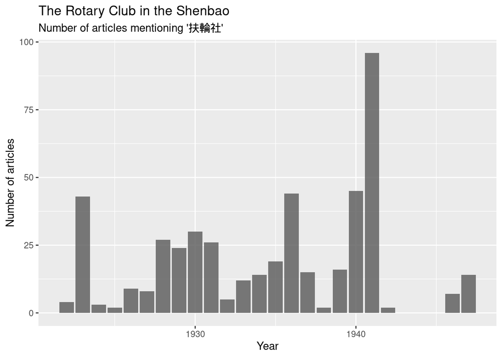

```r
# create variable for years
rotaryzh_100_united <- rotaryzh_100_united %>%
  mutate(year = stringr::str_sub(Date,0,4)) %>%
  mutate(year = as.numeric(year))

rotaryzh_100_united %>%
  group_by(year) %>% count() %>%
  ggplot(aes(x=year, y=n)) +
  geom_col(alpha = 0.8) +
  labs(title = "The Rotary Club in the Shenbao",
       subtitle = "Number of articles mentioning '扶輪社'",
       x = "Year",
       y = "Number of articles")
```

Compute number of characters in each text

```r
rotaryzh_100_united <- rotaryzh_100_united %>% mutate(nchar = nchar(Text))
```

Save and exports results as a csv file:

```r
write.csv(rotaryzh_100_united, "rotaryzh_100_united.csv")
```

## Tokenize the text

The next step is tokenization, which consists in segmenting the Chinese text into meaningful units (tokens, which can be considered as the equivalent of words). For this purpose, we rely on the package [*jieba*](https://github.com/qinwf/jiebaR/). Although *jieba* was initially designed for tokenizing contemporary Chinese texts, it nonetheless gave satisfactory results on our corpus.

Load packages:

```r
library(jiebaR)
library(jiebaRD)
```

Initialize jiebaR worker

```r
cutter <- worker()
```

Test the worker

```r
cutter <- worker()
```

Define the segmenting function

```r
seg_x <- function(x) {str_c(cutter[x], collapse = " ")}
```

Apply the function to each document (row of ltext)

```r
x.out <- sapply(rotaryzh_100_united$Text, seg_x, USE.NAMES = FALSE)
```

Attach the segmented text back to the data frame

```r
rotaryzh_100_united$text.seg <- x.out
```

Inspect the first two rows of the data frame

```r
head(rotaryzh_100_united$text.seg, 2)
```

```
## [1] "家 二十八日 上午 九時 至 十時 半 參觀 各 工廠 十一時 至 十二時 開 演講會 列席 者 聖約翰 大學 學生 十二時 半開 交誼會 列席 者 扶輪社 社員 下午 四時 開 討論會 於 崑山 路 女青年會 列席 者 即 爲 該會 之 幹事 六時 三刻 至 八時 開 演講會 列席 者 南洋 大學 學生 二十"
## [2] "家 二十八日 上午 九時 至 十時 半 參觀 各 工廠 十一時 至 十二時 開 演講會 列席 者 聖約翰 大學 學生 十二時 半開 交誼會 列席 者 扶輪社 社員 下午 四時 開 討論會 於 崑山 路 女青年會 列席 者 即 爲 該會 之 幹事 六時 三刻 至 八時 開 演講會 列席 者 南洋 大學 學生 二十"
```

Count tokens and characters:

```r
library(quanteda)

rotaryzh_100_united <- rotaryzh_100_united %>%
  mutate(ntoken = ntoken(text.seg)) %>%
  mutate(nchar = nchar(Text))
```

## Add metadata

Finally, we incorporate the date of publication into the metadata in view of analyzing topical changes over time. We create different variables for enabling different degrees of temporal granularity.

Create variable for years

```r
rotaryzh_100_united <- rotaryzh_100_united %>%
  mutate(year = stringr::str_sub(Date,0,4)) %>%
  mutate(year = as.numeric(year))
```

Create variable for decades

```r
rotaryzh_100_united$decade <- paste0(substr(rotaryzh_100_united$Date, 0, 3), "0")
```

Create time period based on historian’s prior knowledge on the Rotary Club and of the political context in pre-1949 China:

```r
rotaryzh_100_united$period <- cut(rotaryzh_100_united$year, breaks = c(1919, 1929, 1937, 1948),
                                label = c("1919-1929", "1930-1937", "1938-1948"),
                                include.lowest = TRUE)
```

Select relevant variables

```r
rotaryzh_conc100_corpus <- rotaryzh_100_united %>%
  select(DocId, Source, Title, Text,
         text.seg, nchar, ntoken,
         Date, year, decade, period)
```

Save and export the tokenized corpus

```r
write.csv(rotaryzh_conc100_corpus, "rotaryzh_conc100_corpus.csv")
```

# Pre-processing

Next, we prepare the text data to make it readable by topic model algorithms. We decided to exclude a customized list of stop words, especially the queried terms used to build the corpus (扶輪社) and too common terms in this context (上海, 中國). We removed the words which contained less than 2 characters and occurred in less than 2 documents.

Load packages:

```r
library(stm)
library(stminsights)
```

Pre-processing

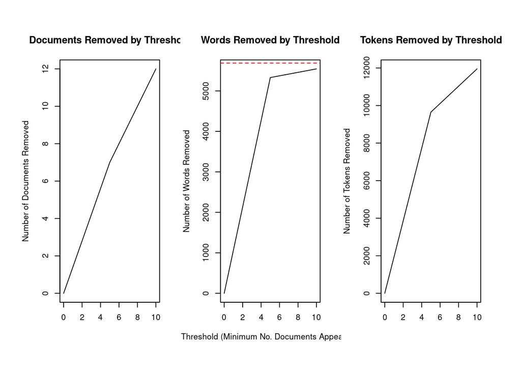

```r
# select metadata
meta <- rotaryzh_conc100_corpus %>% transmute(DocId, Title, Date, year, decade, period, ntoken, nchar)

# create corpus
corpus <- stm::textProcessor(rotaryzh_conc100_corpus$text.seg,
                             metadata = meta,
                             stem = FALSE,
                             wordLengths = c(2, Inf),
                             verbose = FALSE,
                             customstopwords = c("上海", "扶輪社", "中國"))
stm::plotRemoved(corpus$documents, lower.thresh = c(0,10, by=5))
```

```r
out <- stm::prepDocuments(corpus$documents,
                          corpus$vocab,
                          corpus$meta,
                          lower.thresh = 2)
```

```
## Removing 4767 of 5688 terms (5505 of 12414 tokens) due to frequency
## Removing 5 Documents with No Words
## Your corpus now has 462 documents, 921 terms and 6909 tokens.
```

4767 of 5688 terms (5505 of 12414 tokens) were removed due to frequency. 5 Documents with no words were removed (they refer to documents in which the full text has been misplaced in the “title” field). The final corpus contains 462 documents, 921 terms and 6909 tokens.

Before we go on building the models, a sound reflex is to inspect more closely which documents were removed:

```r
out$docs.removed
```

```
## [1] 165 195 280 284 430
```

```r
rotaryzh_conc100_corpus[c(165, 195, 280, 284, 430),  ]
```

| DocId | Source | Title | Text | text.seg | nchar | ntoken | Date | year | decade | period |
| --- | --- | --- | --- | --- | --- | --- | --- | --- | --- | --- |
| SPSP193103271108 | shunpao | 扶輪社昨選新聯員 | 扶輪社昨選新聯員 | 扶輪社 昨選 新聯 員 | 8 | 6 | 19310327 | 1931 | 1930 | 1930-1937 |
| SPSP193401281520 | shunpao | 燕大校長塞替阿博士演講「中國之大學生」 | 昨應扶輪社之請 | 昨應 扶輪社 之 請 | 7 | 5 | 19340128 | 1934 | 1930 | 1930-1937 |
| SPSP193706050418 | shunpao | 鎮扶輪社將開授證慶祝會 | 鎮扶輪社將開授證慶祝會 | 鎮 扶輪社 將開 授證 慶祝會 | 11 | 7 | 19370605 | 1937 | 1930 | 1930-1937 |
| SPSP193710090605 | shunpao | 扶輪社計畫流動醫藥車 | 扶輪社計畫流動醫藥車 | 扶輪社 計畫 流動 醫藥 車 | 10 | 5 | 19371009 | 1937 | 1930 | 1930-1937 |
| SPSP194110261203 | shunpao | 上海扶輪社 今晨映免費電影 新影 | 上海扶輪社今晨映免費電影 新影 | 上海 扶輪社 今晨 映 免費電影 新影 | 16 | 8 | 19411026 | 1941 | 1940 | 1938-1948 |

Similarly, let’s examine the words that were removed:

```r
wordsremoved <- as_tibble(out$words.removed)
wordsremoved
```

| value |
| --- |
| blo |
| coulouras |
| drhirambingham |
| england |
| eveleig |
| fitch |
| frawl |
| frawley |
| georgea |
| hobson |

[output cut: 4757 more lines]

We notice that many of the removed words are English words inserted in the Chinese text.

# Model building

Choosing the right number of topics *k* remains a highly debated question. There is no definite solution. Most topic modeling tools generally provide a set of metrics such as held-out likelihood, residual analysis, average exclusivity and semantic coherence, to help the researcher to determine the optimal number of topics for a given corpus. According to the authors of the [manual of the stm package](https://cran.r-project.org/web/packages/stm/stm.pdf), for small corpora ranging from a few hundred to a few thousand documents, the best number of topics should range between 5 and 50 topics [^2]. Ultimately, however, only the researcher’s interpretational needs can determine what is the most appropriate number of topics for a given specific research.

In the stm R package, the *searchK* function provides a wide range of metrics to guide our choice, including held-out likelihood, residual analysis, average exclusivity and semantic coherence. Only the default properties (held-out likelihood, residuals, semantic coherence, lower bound) are displayed below:

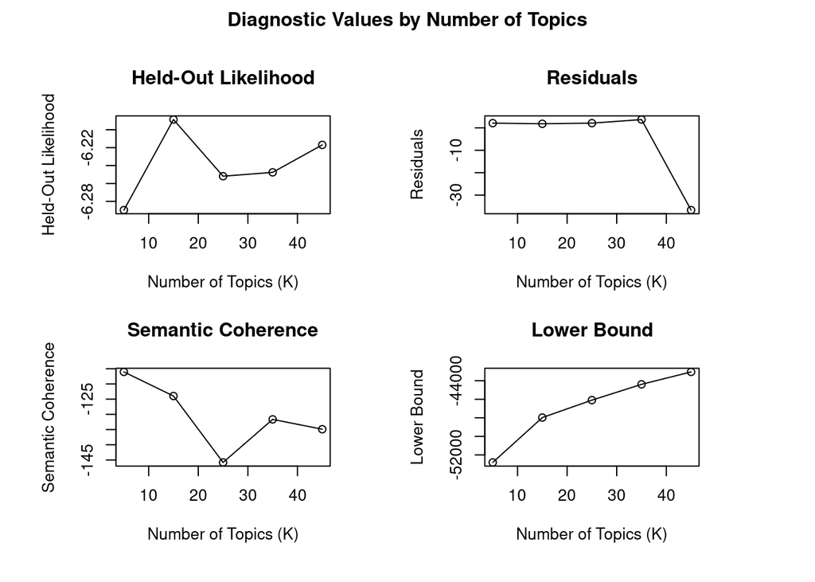

```r
set.seed(1111)
K<-seq(5,50, by=10)
kresult <- searchK(out$documents, out$vocab, K, prevalence =~ year, data=out$meta, verbose=FALSE)
plot(kresult)
```

After several experiments, we decided build three models with 5, 10 and 20 topics, which will enable us to navigate different levels of granularity:

```r
# 5-topic model
mod.5 <- stm::stm(out$documents,
                   out$vocab, K=5,
                   prevalence =~ year,
                   data=out$meta, verbose = FALSE)

# 10-topic model
mod.10 <- stm::stm(out$documents,
                   out$vocab, K=10,
                   prevalence =~ year,
                   data=out$meta, verbose = FALSE)

# 20-topic model
mod.20 <- stm::stm(out$documents,
                   out$vocab, K=20,
                   prevalence =~ year,
                   data=out$meta, verbose = FALSE)
```

Next, we incorporate the time variables in the models to further analyze topical changes over time:

```r
year5 <- stm::estimateEffect(1:5 ~ year, mod.5, meta=out$meta)
year10 <- stm::estimateEffect(1:10 ~ year, mod.10, meta=out$meta)
year20 <- stm::estimateEffect(1:20 ~ year, mod.20, meta=out$meta)
```

Finally, we save the models as an “.RData” file to save time and computational power in the future:

```r
save.image('rotaryzh.RData')
```

# Model evaluation

To compare the three models, we can plot the semantic coherence of topics against their exclusivity. As the plot suggested, the higher the number of topics, the lower their semantic coherence, and the higher their exclusivity:

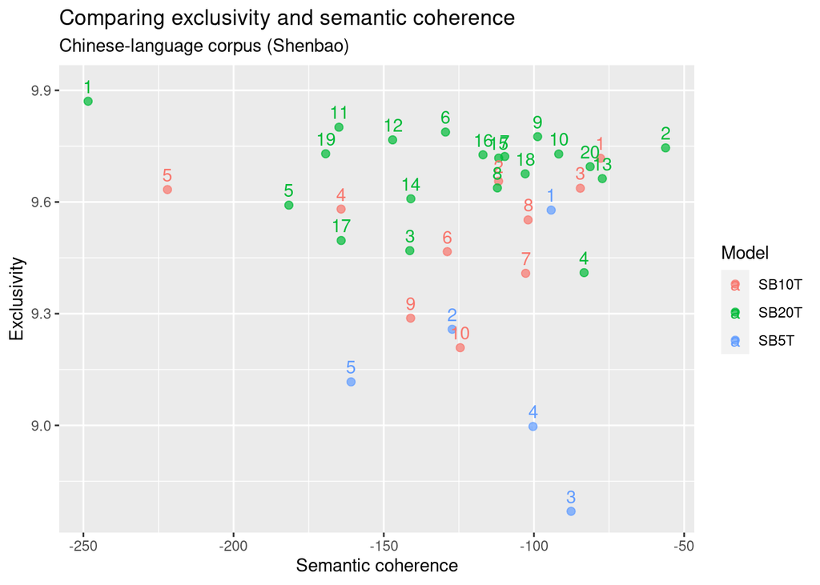

```r
mod5df<-as.data.frame(cbind(c(1:5),exclusivity(mod.5), semanticCoherence(model=mod.5, out$documents), "SB5T"))
mod10df<-as.data.frame(cbind(c(1:10),exclusivity(mod.10), semanticCoherence(model=mod.10, out$documents), "SB10T"))
mod20df<-as.data.frame(cbind(c(1:20),exclusivity(mod.20), semanticCoherence(model=mod.20, out$documents), "SB20T"))

models<-rbind(mod5df, mod10df, mod20df)
colnames(models)<-c("Topic","Exclusivity", "SemanticCoherence", "Model")

models$Exclusivity<-as.numeric(as.character(models$Exclusivity))
models$SemanticCoherence<-as.numeric(as.character(models$SemanticCoherence))

options(repr.plot.width=7, repr.plot.height=6, repr.plot.res=100)

plotmodels <-ggplot(models, aes(SemanticCoherence, Exclusivity, color = Model))+
  geom_point(size = 2, alpha = 0.7) +
  geom_text(aes(label=Topic), nudge_y=.04)+
  labs(x = "Semantic coherence",
       y = "Exclusivity",
       title = "Comparing exclusivity and semantic coherence",
       subtitle = "Chinese-language corpus (Shenbao)")


plotmodels
```

# Model exploration

In the first step, we highly recommend using the package [stminsights](https://cran.r-project.org/web/packages/stminsights/vignettes/intro.html) to explore the models:

```r
library(stminsights)
run_stminsights()
```

[Stminsights](https://cran.r-project.org/web/packages/stminsights/vignettes/intro.html) is an R Shiny application which provides a set of visualizations and statistical tools for exploring the topics in one or across multiple models. While building on the stm package itself, it greatly facilitates the preliminary exploration. In the next sections, we shall provide the full code for reproducing and adjusting the outputs produced through the “stm insights” application.

## Topic proportions θ

Extract topic proportions for each model:

```r
topicprop5<-make.dt(mod.5, meta)
topicprop10<-make.dt(mod.10, meta)
topicprop20<-make.dt(mod.20, meta)
```

Consulting the table might be a bit cumbersome unless we want to examine the topic proportions of a specific document. The “plot.STM” function associated with the “hist” argument helps to better visualize the estimates of document-topic proportions:

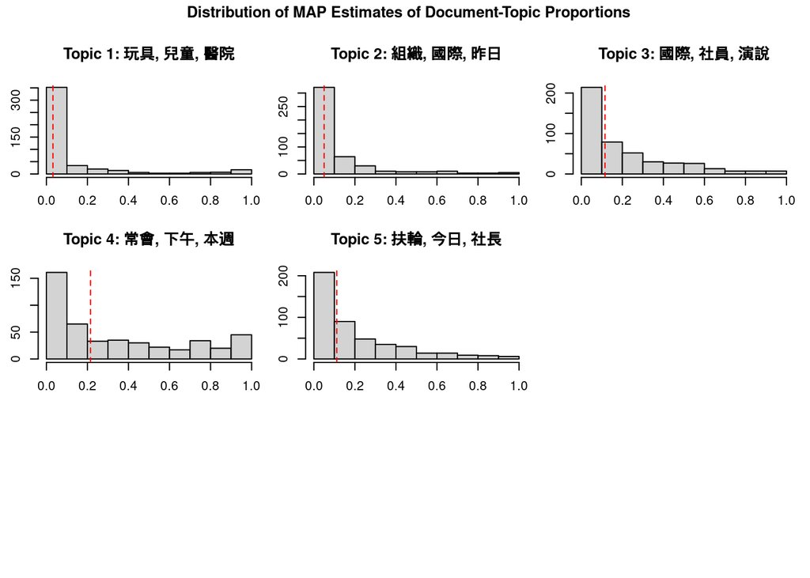

```r
plot.STM(mod.5, "hist")
```

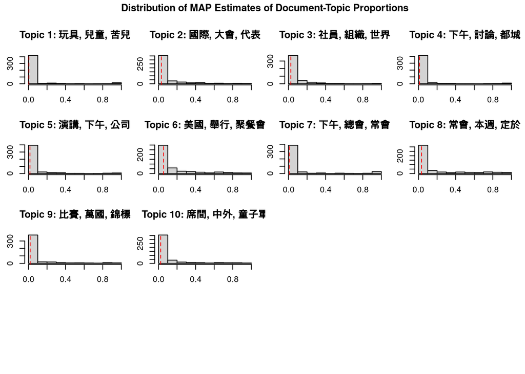

```r
plot.STM(mod.10, "hist")
```

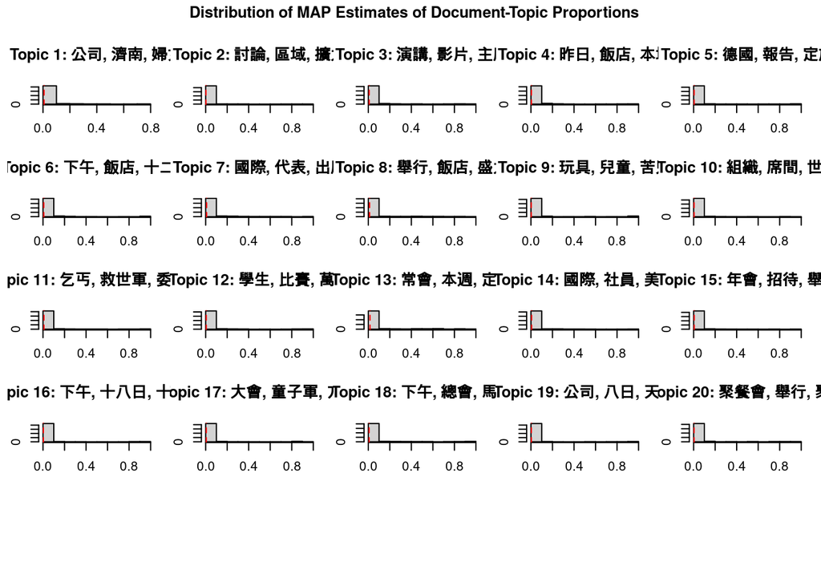

```r
plot.STM(mod.20, "hist")
```

Next, we can examine more closely the words that define the topics in order to better understand what each topic is really about.

## Word per topic β

In the stm package, the function “plot.STM” with argument “summary” displays the general distribution of topics (which topics are overall more common in the corpus) along with the most common words for each topic. In the example below, we set the number of desired words to 5:

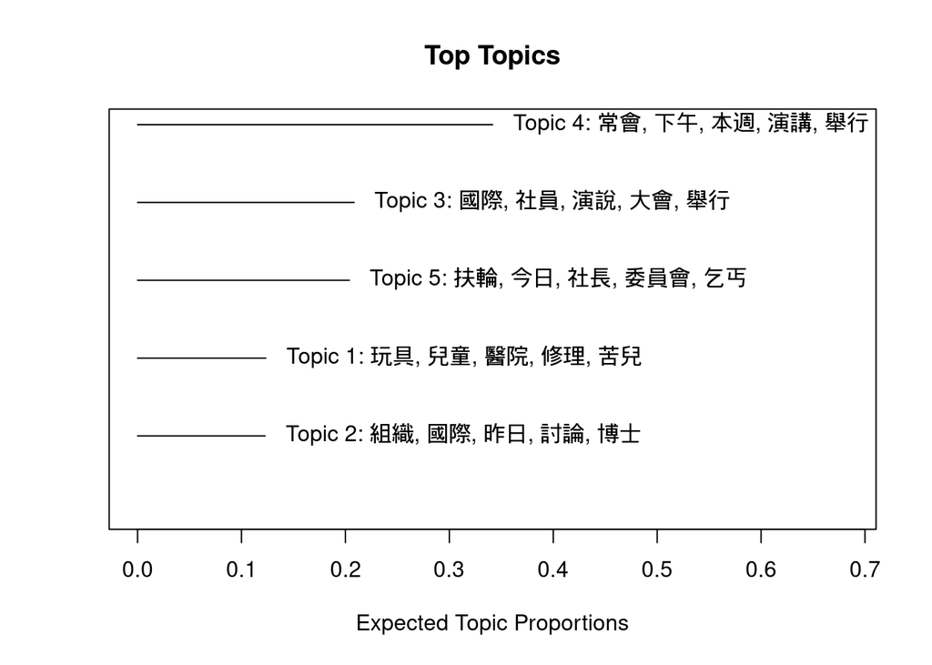

```r
plot.STM(mod.5,"summary", n=5)
```

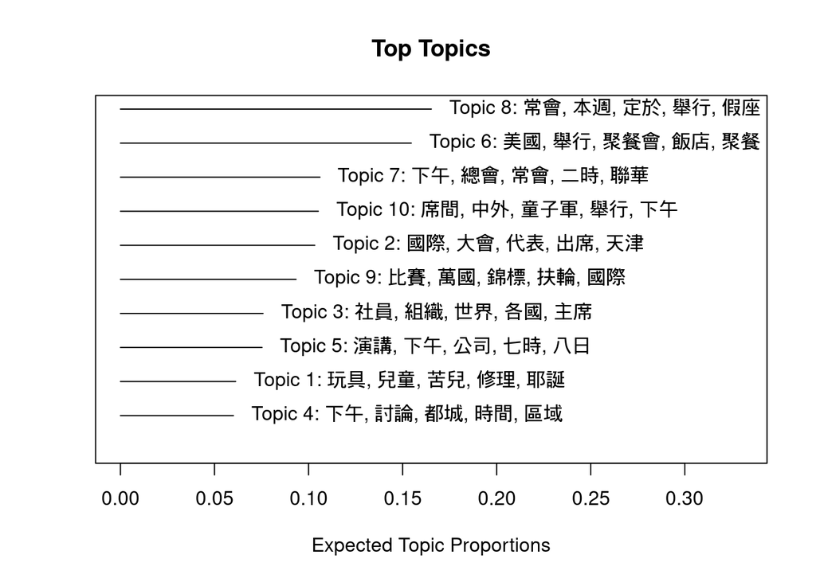

```r
plot.STM(mod.10, "summary", n=5)
```

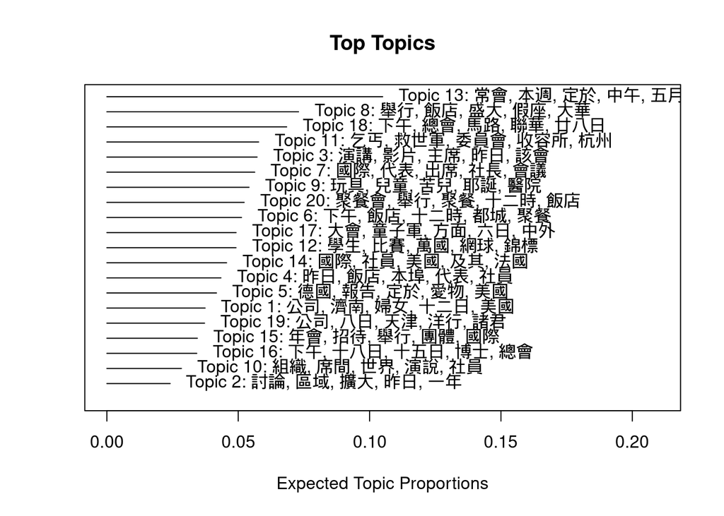

```r
plot.STM(mod.20, "summary", n=5)
```

Alternatively, we can plot words proportions per topics as bar plots using a tidy approach. In the example below, we focus on the 10-topic model:

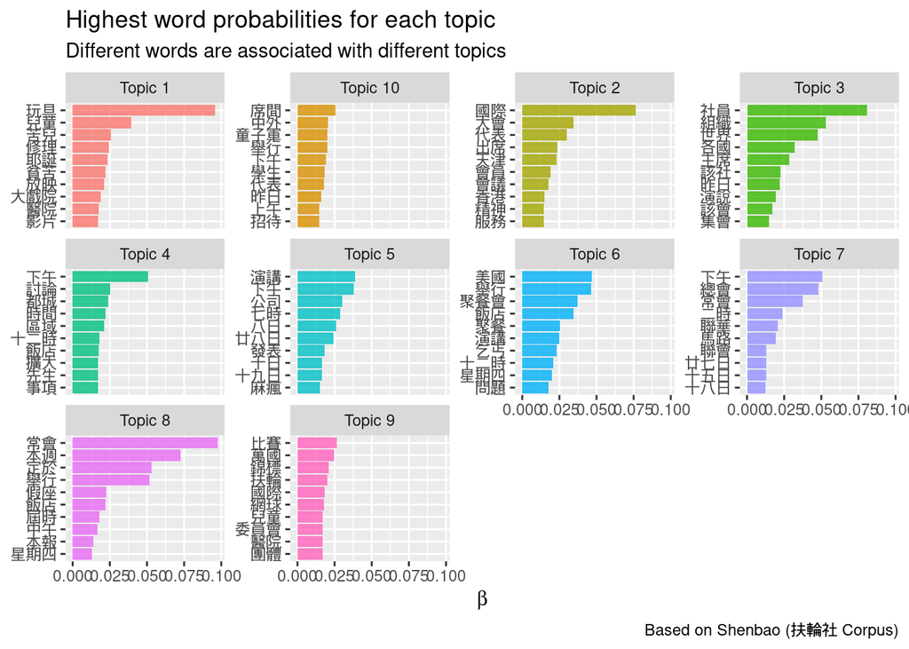

```r
# load packages

library(tidyverse)
library(tidytext)

td_beta10_zh <- tidytext::tidy(mod.10)

options(repr.plot.width=7, repr.plot.height=8, repr.plot.res=100)

td_beta10_zh %>%
  group_by(topic) %>%
  top_n(10, beta) %>%
  ungroup() %>%
  mutate(topic = paste0("Topic ", topic),
         term = reorder_within(term, beta, topic)) %>%
  ggplot(aes(term, beta, fill = as.factor(topic))) +
  geom_col(alpha = 0.8, show.legend = FALSE) +
  facet_wrap(~ topic, scales = "free_y") +
  coord_flip() +
  scale_x_reordered() +
  labs(x = NULL, y = expression(beta),
       title = "Highest word probabilities for each topic",
       subtitle = "Different words are associated with different topics",
       caption = "Based on Shenbao (扶輪社 Corpus)")
```

Let’s explore the top 10 words for each topic:

```r
topic10zh_top_words <- td_beta10_zh %>%
  group_by(topic) %>%
  top_n(10, beta)

topic10zh_top_words %>% arrange(topic, desc(beta))
```

| topic | term | beta |
| --- | --- | --- |
| 1 | 玩具 | 0.09564360 |
| 1 | 兒童 | 0.03954789 |
| 1 | 苦兒 | 0.02557910 |
| 1 | 修理 | 0.02448077 |
| 1 | 耶誕 | 0.02335483 |
| 1 | 貧苦 | 0.02224270 |
| 1 | 放映 | 0.02113056 |
| 1 | 大戲院 | 0.01890629 |
| 1 | 醫院 | 0.01767467 |
| 1 | 影片 | 0.01705056 |

[output cut: 90 more lines]

## Topic labeling

The function “labelTopics” (or sageLabels) provides a deeper insight on the popular words in each topic. In addition to words probabilities, other metrics can be computed, including the FREX words (FREX weights words by frequency and exclusivity to the topic), lift words (frequency divided by frequency in other topics), and score (similar to lift, but with log frequencies). In the example below, we set the number of words to 10:

```r
labelTopics(mod.5, n=10)
```

```
## Topic 1 Top Words:
##       Highest Prob: 玩具, 兒童, 醫院, 修理, 苦兒, 團體, 耶誕, 貧苦, 放映, 徵求
##       FREX: 玩具, 兒童, 醫院, 修理, 苦兒, 耶誕, 貧苦, 放映, 市長, 大戲院
##       Lift: 不知, 中山, 之後, 事務, 二十四日, 免費, 入座, 公用局, 募集, 北上
##       Score: 玩具, 兒童, 苦兒, 耶誕, 貧苦, 大戲院, 放映, 破舊, 徵集, 醫院
## Topic 2 Top Words:
##       Highest Prob: 組織, 國際, 昨日, 討論, 博士, 年會, 全國, 學生, 該會, 會長
##       FREX: 學生, 區域, 紀念會, 衛生, 擴大, 一年, 百餘人, 一百, 八十一, 發生
##       Lift: 二十餘, 共有, 創立, 廳長, 擴大, 案件, 永久, 盛况, 致力, 評判員
##       Score: 擴大, 紀念會, 一年, 一百, 會長, 區域, 組織, 全國, 擔任, 討論
## Topic 3 Top Words:
##       Highest Prob: 國際, 社員, 演說, 大會, 舉行, 昨日, 美國, 代表, 主席, 世界
##       FREX: 此次, 目的, 日本, 及其, 人士, 親善, 努力, 和平, 吾人, 昨在
##       Lift: 一人, 三年, 主持, 二十六日, 交涉, 人士, 人類, 全球, 共同, 最大
##       Score: 國際, 親善, 目的, 此次, 代表, 席間, 演說, 童子軍, 發表, 世界
## Topic 4 Top Words:
##       Highest Prob: 常會, 下午, 本週, 演講, 舉行, 總會, 定於, 飯店, 十二時, 星期四
##       FREX: 常會, 本週, 十二時, 聯華, 三十分, 五月, 八日, 十八日, 今午, 廿八日
##       Lift: 三十分, 九畝, 事項, 二十七日, 五時, 五時半, 休息, 先生, 入社, 八十週年
##       Score: 常會, 本週, 下午, 聯華, 十二時, 廿八日, 事項, 總會, 今午, 八日
## Topic 5 Top Words:
##       Highest Prob: 扶輪, 今日, 社長, 委員會, 乞丐, 會議, 出席, 天津, 問題, 公司
##       FREX: 扶輪, 委員會, 乞丐, 問題, 錦標, 救世軍, 香港, 收容所, 太平洋, 諸君
##       Lift: 一部, 世運, 事畢, 二十一日, 人員, 兩國, 公使, 出口, 協助, 原定
##       Score: 乞丐, 扶輪, 救世軍, 諸君, 收容所, 光明, 香港, 出席, 錦標, 天津
```

```r
labelTopics(mod.10, n=10)
```

```
## Topic 1 Top Words:
##       Highest Prob: 玩具, 兒童, 苦兒, 修理, 耶誕, 貧苦, 放映, 大戲院, 醫院, 影片
##       FREX: 玩具, 苦兒, 耶誕, 貧苦, 放映, 大戲院, 破舊, 徵集, 一件, 照例
##       Lift: 貧苦, 不知, 多少, 小朋友, 微集, 徵集, 慈幼, 我們, 敬向, 有着
##       Score: 玩具, 耶誕, 苦兒, 大戲院, 徵集, 破舊, 照例, 兒童, 公映, 時節
## Topic 2 Top Words:
##       Highest Prob: 國際, 大會, 代表, 出席, 天津, 會員, 會議, 香港, 精神, 服務
##       FREX: 香港, 各地, 此間, 出席, 天津, 法國, 總統, 國際, 服務, 會議
##       Lift: 創立, 歡迎會, 獎學金, 第六, 籌備, 號輪, 訪問, 閉幕, 各地, 外交部長
##       Score: 國際, 天津, 各地, 香港, 代表, 大會, 親善, 出席, 外交部長, 閉幕
## Topic 3 Top Words:
##       Highest Prob: 社員, 組織, 世界, 各國, 主席, 該社, 昨日, 演說, 該會, 集會
##       FREX: 衛生, 社員, 世界, 各國, 國籍, 組織, 集會, 主席, 最大, 國民
##       Lift: 交涉, 最大, 國民, 沿海, 名譽, 國籍, 歐洲, 衛生, 四年, 一面
##       Score: 世界, 組織, 社員, 國籍, 親善, 目的, 衛生, 集會, 沿海, 大城市
## Topic 4 Top Words:
##       Highest Prob: 下午, 討論, 都城, 時間, 區域, 十二時, 飯店, 擴大, 事項, 先生
##       FREX: 擴大, 事項, 先生, 一年, 一百, 八仙, 區域, 愛物, 擔任, 江西
##       Lift: 五時半, 擴大, 每日, 研究班, 誦經, 一年, 一百, 並將, 事項, 先生
##       Score: 事項, 擴大, 宴會, 八仙, 一百, 星期五, 並將, 一年, 區域, 大城市
## Topic 5 Top Words:
##       Highest Prob: 演講, 下午, 公司, 七時, 八日, 廿八日, 發表, 十日, 十九日, 麻瘋
##       FREX: 七時, 八日, 廿八日, 發表, 麻瘋, 浦東, 畢業, 通過, 事件, 十九日
##       Lift: 北上, 南門, 商團, 專科, 師範學校, 日軍, 東門, 發表, 碩士, 總幹事
##       Score: 八日, 廿八日, 浦東, 禁止, 休業, 永年, 沙田, 福利, 七時, 練習
## Topic 6 Top Words:
##       Highest Prob: 美國, 舉行, 聚餐會, 飯店, 聚餐, 演講, 乞丐, 十二時, 星期四, 問題
##       FREX: 乞丐, 救世軍, 今午, 收容所, 聚餐會, 本屆, 自由, 星期, 社友, 情形
##       Lift: 兩國, 完成, 收容所, 由於, 積極, 今午, 卡爾登, 多邀, 改於, 救世軍
##       Score: 今午, 聚餐會, 乞丐, 救世軍, 收容所, 社友, 十二時, 聚餐, 三十分, 美國
## Topic 7 Top Words:
##       Highest Prob: 下午, 總會, 常會, 二時, 聯華, 馬路, 聯會, 廿七日, 十五日, 十八日
##       FREX: 聯會, 八十一, 六日, 外灘, 漢口路, 陳列, 馬路, 廿七日, 光明, 總會
##       Lift: 九畝, 八十週年, 午三, 天后宫, 山東, 工業, 民國, 没心肝, 納税, 育會
##       Score: 八十一, 常會, 聯華, 光明, 外灘, 漢口路, 納税, 總會, 馬路, 下午
## Topic 8 Top Words:
##       Highest Prob: 常會, 本週, 定於, 舉行, 假座, 飯店, 屆時, 中午, 本報, 星期四
##       FREX: 本週, 定於, 屆時, 大華, 駐華, 假座, 本報, 常會, 中央, 將由
##       Lift: 二十四日, 入社, 公使, 播音, 不及, 俄童, 大華, 將由, 探悉, 本週
##       Score: 本週, 常會, 定於, 五月, 週會, 將由, 假座, 屆時, 公使, 俄童
## Topic 9 Top Words:
##       Highest Prob: 比賽, 萬國, 錦標, 扶輪, 國際, 網球, 兒童, 委員會, 醫院, 團體
##       FREX: 網球, 贈送, 錦標, 優勝者, 歷年, 紅十字會, 比賽, 網球賽, 萬國, 著名
##       Lift: 募集, 基金, 截止, 拳擊賽, 施行, 案件, 殘廢, 永久, 童子, 虹橋路
##       Score: 網球, 比賽, 錦標, 幼童, 萬國, 兒童, 扶輪, 網球賽, 贈送, 紅十字會
## Topic 10 Top Words:
##       Highest Prob: 席間, 中外, 童子軍, 舉行, 下午, 學生, 代表, 昨日, 上午, 招待
##       FREX: 席間, 童子軍, 德國, 注意, 列席, 學生, 中外, 參觀, 市長, 招待
##       Lift: 公用局, 參加者, 夫婦, 新聞, 領袖, 二十, 創設, 吳鐵城, 報紙, 孔祥熙
##       Score: 席間, 列席, 童子軍, 中外, 市長, 杭州, 學生, 紀錄, 第一, 來賓
```

```r
labelTopics(mod.20, n=10)
```

```
## Topic 1 Top Words:
##       Highest Prob: 公司, 濟南, 婦女, 十二日, 美國, 明日, 本周, 耶誕節, 夫人, 霞飛路
##       FREX: 婦女, 濟南, 本周, 耶誕節, 公司, 十二日, 霞飛路, 明日, 廿五日, 一行
##       Lift: 本周, 耶誕節, 北上, 霞飛路, 婦女, 濟南, 十二日, 一行, 並請, 設備
##       Score: 本周, 耶誕節, 濟南, 公司, 十二日, 婦女, 廿五日, 霞飛路, 明日, 此外
## Topic 2 Top Words:
##       Highest Prob: 討論, 區域, 擴大, 昨日, 一年, 一百, 進行, 增加, 成立, 下午
##       FREX: 擴大, 一百, 一年, 區域, 決議, 討論, 增加, 擔任, 休業, 進行
##       Lift: 商團, 閉幕, 休業, 決議, 一百, 擴大, 第九十七, 一年, 擔任, 區域
##       Score: 擴大, 一百, 區域, 一年, 增加, 擔任, 決議, 大城市, 目標, 並將
## Topic 3 Top Words:
##       Highest Prob: 演講, 影片, 主席, 昨日, 該會, 馬來, 昨在, 世界, 飯店, 組織
##       FREX: 演講, 馬來, 影片, 昨在, 經理, 麻瘋, 慶祝, 放映, 人民, 關於
##       Lift: 沿海, 聽者, 經理, 馬來, 孔雀, 貨幣, 勝利, 過去, 上海市, 演講
##       Score: 演講, 馬來, 影片, 經理, 沿海, 麻瘋, 人民, 社友, 孔雀, 自由
## Topic 4 Top Words:
##       Highest Prob: 昨日, 飯店, 本埠, 代表, 社員, 舉行, 該社, 會員, 來賓, 主席
##       FREX: 昨日, 宴會, 來賓, 起立, 邀請, 十餘, 登君, 中西, 本埠, 本報
##       Lift: 宴會, 登君, 市政府, 當晚, 起立, 十餘, 紳商, 循例, 邀請, 創設
##       Score: 宴會, 來賓, 昨日, 起立, 已有, 飯店, 登君, 列席, 紳商, 十餘
## Topic 5 Top Words:
##       Highest Prob: 德國, 報告, 定於, 愛物, 美國, 展覽會, 加入, 十一月, 中華, 童子軍
##       FREX: 德國, 愛物, 我們, 消息, 十一月, 加入, 展覽會, 禁止, 報告, 各校
##       Lift: 優良, 評判員, 愛物, 德國, 禁止, 案件, 我們, 正在, 報紙, 各校
##       Score: 德國, 禁止, 愛物, 消息, 加入, 展覽會, 我們, 報告, 報紙, 十一月
## Topic 6 Top Words:
##       Highest Prob: 下午, 飯店, 十二時, 都城, 聚餐, 今日, 今午, 時間, 中午, 事項
##       FREX: 今午, 事項, 八仙, 江西, 十二時, 先生, 時間, 都城, 今日, 地點
##       Lift: 事項, 五時半, 研究班, 誦經, 八仙, 樂隊, 江西, 演奏, 今午, 先生
##       Score: 今午, 事項, 八仙, 十二時, 都城, 球隊, 聚餐, 時間, 星期五, 江西
## Topic 7 Top Words:
##       Highest Prob: 國際, 代表, 出席, 社長, 會議, 開會, 香港, 大會, 協會, 全國
##       FREX: 會議, 八十一, 香港, 出席, 社長, 太平洋, 創立, 籌備, 開會, 代表
##       Lift: 創立, 籌備, 八十一, 總社, 世運, 號輪, 東京, 太平洋, 昨晚, 香港
##       Score: 八十一, 國際, 香港, 代表, 創立, 出席, 社長, 各地, 籌備, 會議
## Topic 8 Top Words:
##       Highest Prob: 舉行, 飯店, 盛大, 假座, 大華, 本埠, 跳舞會, 紀念, 學校, 本月
##       FREX: 大華, 跳舞會, 建築, 盛大, 公使, 學校, 舉行, 俄童, 二十四日, 紀念
##       Lift: 入社, 公用局, 俄童, 公使, 建築, 週會, 大華, 二十四日, 跳舞會, 商務
##       Score: 大華, 舉行, 俄童, 週會, 跳舞會, 建築, 盛大, 公使, 飯店, 紀念
```

[output cut: 45 more lines]

```
## Topic 18 Top Words:
##       Highest Prob: 下午, 總會, 馬路, 聯華, 廿八日, 協會, 四川, 廿七日, 二時, 租界
##       FREX: 廿八日, 馬路, 廿七日, 五時, 約翰, 聯華, 四川, 租界, 納税, 總會
##       Lift: 納税, 午三, 南門, 專科, 師範學校, 茶會, 茶話會, 附屬中學, 中學, 召開
##       Score: 廿八日, 下午, 聯華, 廿七日, 約翰, 馬路, 納税, 四川, 五時, 總會
## Topic 19 Top Words:
##       Highest Prob: 公司, 八日, 天津, 洋行, 諸君, 五日, 對於, 光明, 商會, 目的
##       FREX: 八日, 洋行, 光明, 諸君, 永年, 沙田, 福利, 日前, 足以, 略謂
##       Lift: 東門, 没心肝, 二三, 二二, 光明, 八日, 新光, 永年, 沙田, 油漆
##       Score: 洋行, 八日, 光明, 天津, 諸君, 永年, 沙田, 福利, 二三, 二二
## Topic 20 Top Words:
##       Highest Prob: 聚餐會, 舉行, 聚餐, 十二時, 飯店, 三十分, 社員, 演說, 星期四, 於今
##       FREX: 聚餐會, 三十分, 聚餐, 於今, 十二時, 社友, 第六, 宗旨, 檀香山, 改於
##       Lift: 改於, 聚餐會, 多邀, 於今, 第六, 午間, 三十分, 卡爾, 本日, 半在
##       Score: 聚餐會, 聚餐, 十二時, 於今, 社友, 檀香山, 三十分, 改於, 星期四, 飯店
```

For example, we can display the 10 FREX words for selected topics (1 and 3) in the 10-topic model:

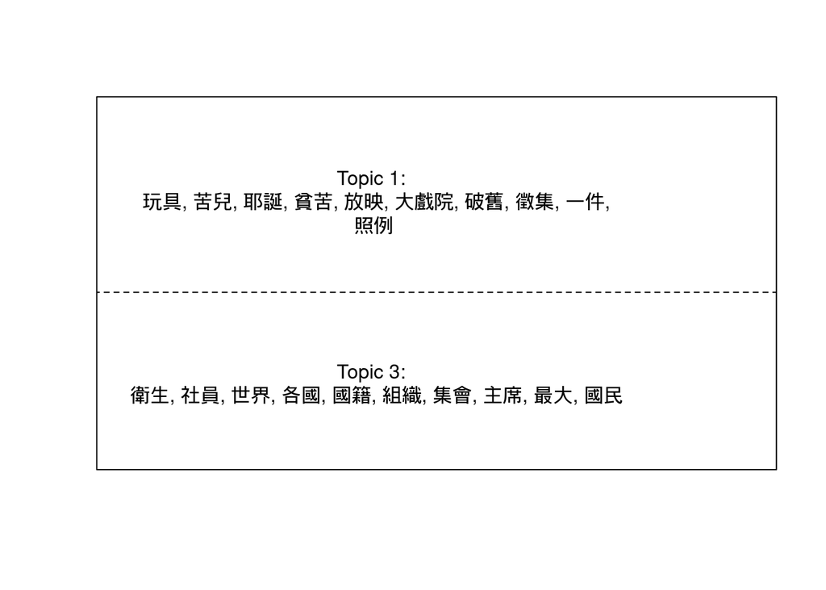

```r
plot.STM(mod.10, "labels", topics=c(1,3), label="frex", n=10, width=60)
```

## Word clouds

Word clouds provide a more intuitive way of visualizing word prevalence in topics. The example below displays the word clouds of the two “international” topics (2 and 3):

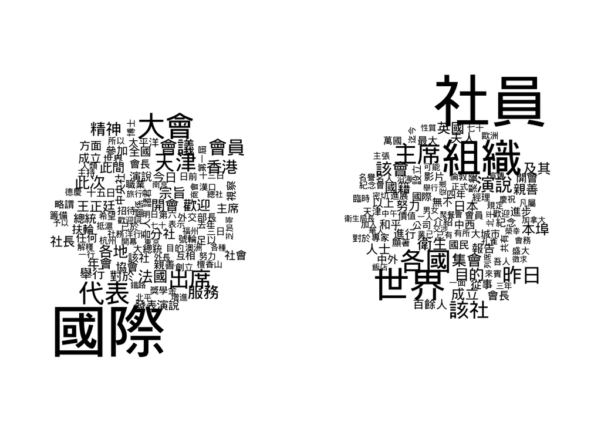

```r
par(mfrow=c(1,2), mar=c(0,0,2,2))
cloud(mod.10, topic = 2, scale = c(4, 0.4))
cloud(mod.10, topic = 3, scale = c(4, 0.4))
```

## Perspective

We can use the “perspective” argument to compare topics two by two. This function is helpful to better distinguish between topics that share many similar words. For instance, we can compare two internationally minded topics (2 and 3) in the 10-topic model:

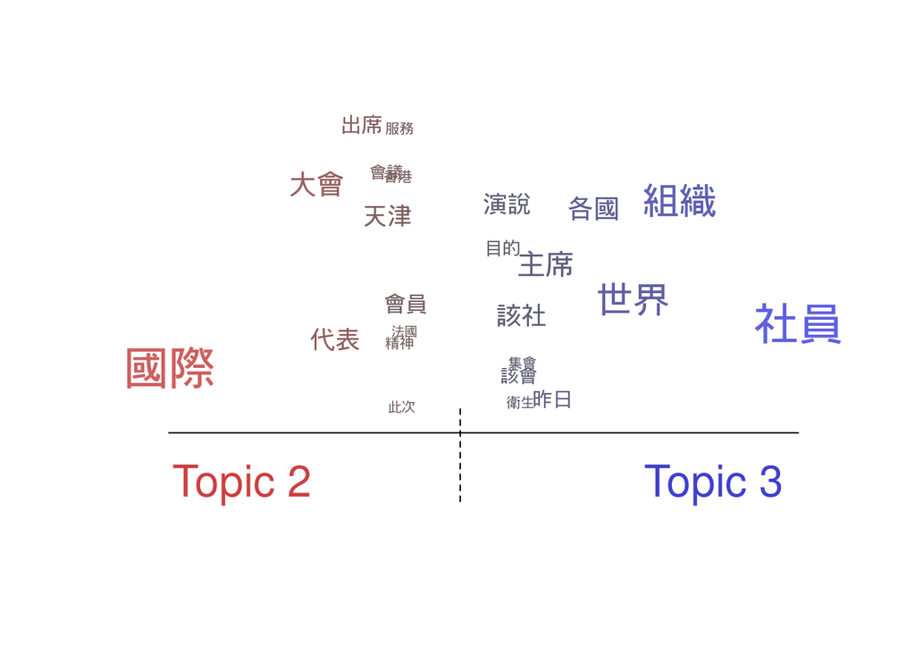

```r
par(mfrow=c(1,1))
plot(mod.10, type="perspectives", topics=c(2, 3))
```

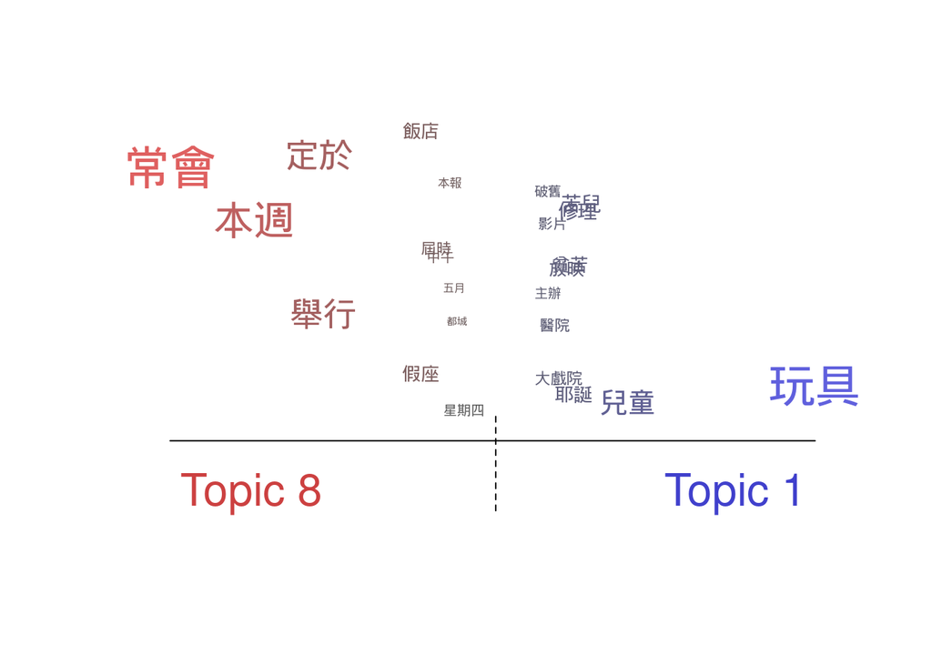

```r
par(mfrow=c(1,1))
plot(mod.10, type="perspectives", topics=c(8, 1))
```

## Quotations

Some topics may still be unclear and require that we closely look at a sample of representative documents in order to better understand how words translate into concrete sentences in the original articles. To retrieve the representative documents for a given topic, we can use the “findThoughts” function and then display the documents with the companion function “plotQuote”:

To apply this function, we first need to remove the five documents that were eliminated during the pre-processing:

```r
docremoved <- rotaryzh_conc100_corpus[-c(165, 195, 280, 284, 430),  ]
```

Then, we can extract and plot the 3 most representative documents for topics 1 and 3:

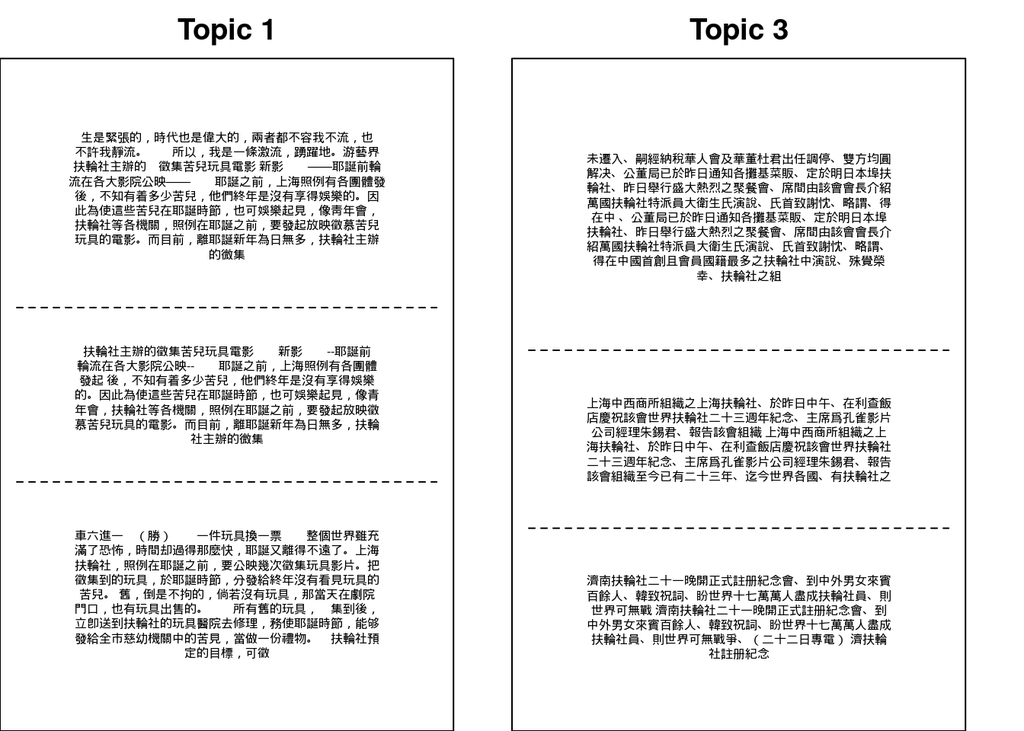

```r
thoughts1 <- findThoughts(mod.10,texts=docremoved$Text, topics=1, n=3)$docs[[1]]
thoughts3 <- findThoughts(mod.10,texts=docremoved$Text, topics=3, n=3)$docs[[1]]

par(mfrow=c(1,2), mar=c(0,0,2,2))
plotQuote(thoughts1, width=50, maxwidth=500, text.cex=0.5, main="Topic 1")
plotQuote(thoughts3, width=50, maxwidth=500, text.cex=0.5, main="Topic 3")
```

## Topic correlation

Topic correlation serves to map connections between topics in a given model. The relations between the topics are based on the proportions of the words they have in common. The “stm” package provides two options for estimating topic correlations. The “simple” method simply thresholds the covariances, whereas the “huge” method uses a semi-parametric procedure. Let’s compare the two approaches:

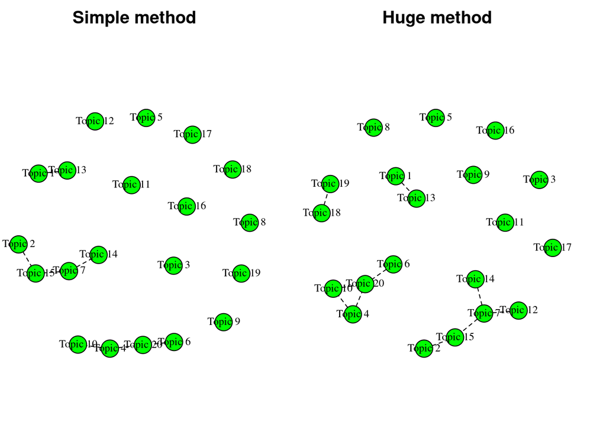

```r
corrsimple <- topicCorr(mod.20, method = "simple", verbose = FALSE)
corrhuge <- topicCorr(mod.20, method = "huge", verbose = FALSE)
par(mfrow=c(1,2), mar=c(0,0,2,2))
plot(corrsimple, main = "Simple method")
plot(corrhuge, main = "Huge method")
```

We can then use the package [gggraph](https://exts.ggplot2.tidyverse.org/ggraph.html) to better visualize topic proportions by adding weights to the links:

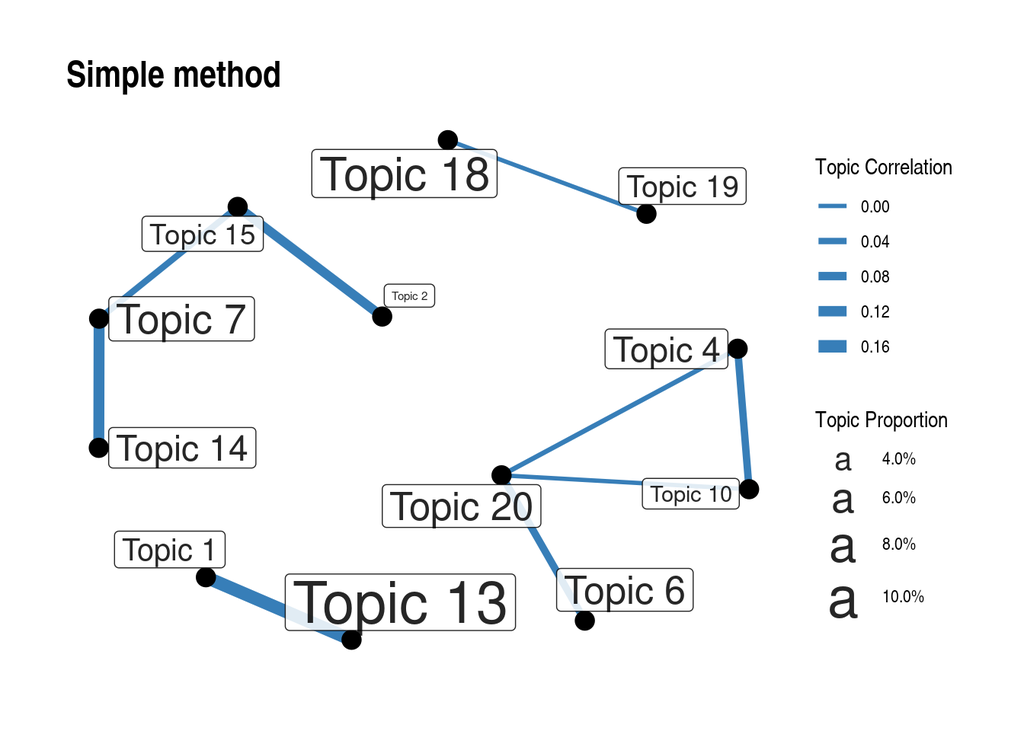

```r
# extract network
stm_corrs <- get_network(model = mod.20,
                         method = 'simple',
                         labels = paste('Topic', 1:20),
                         cutoff = 0.001,
                         cutiso = TRUE)

# plot network with ggraph
library(ggraph)

ggraph(stm_corrs, layout = 'fr') +
  geom_edge_link(
    aes(edge_width = weight),
    label_colour = '#fc8d62',
    edge_colour = '#377eb8') +
  geom_node_point(size = 4, colour = 'black')  +
  geom_node_label(
    aes(label = name, size = props),
    colour = 'black',  repel = TRUE, alpha = 0.85) +
  scale_size(range = c(2, 10), labels = scales::percent) +
  labs(size = 'Topic Proportion',  edge_width = 'Topic Correlation', title = "Simple method") +
  scale_edge_width(range = c(1, 3)) +
  theme_graph()
```

## Interactive visualization

The “stm” package also includes a “LDAvis” function which produces an interactive visualization of an LDA topic model. The main graphical elements include:

- Default topic circles - K circles, one for each topic, whose areas are set to be proportional to the proportions of the topics across the N total tokens in the corpus.
- Red bars - represent the estimated number of times a given term was generated by a given topic.
  - Blue bars - represent the overall frequency of each term in the corpus
  - Topic-term circles - K×W circles whose areas are set to be proportional to the frequencies with which a given term is estimated to have been generated by the topics.

```r
stm::toLDAvis(mod.5, doc=out$documents)
stm::toLDAvis(mod.10, doc=out$documents)
stm::toLDAvis(mod.20, doc=out$documents)
```

# Topics over time

In this section, we analyze the effect of time (date of publication) on topic prevalence in the three models.

First, select topic proportions

```r
topic5prop <- topicprop5 %>% select(c(2:6))
topic10prop <- topicprop10 %>% select(c(2:11))
topic20prop <- topicprop20 %>% select(c(2:21))
```

Compute topic proportions per year

```r
topic_proportion_per_year5 <- aggregate(topic5prop, by = list(Year = rotaryzh_conc100_corpus$year), mean)
topic_proportion_per_year10 <- aggregate(topic10prop, by = list(Year = rotaryzh_conc100_corpus$year), mean)
topic_proportion_per_year20 <- aggregate(topic20prop, by = list(Year = rotaryzh_conc100_corpus$year), mean)
```

Reshape data frame

```r
library(reshape)
vizDataFrame5y <- melt(topic_proportion_per_year5, id.vars = "Year")
vizDataFrame10y <- melt(topic_proportion_per_year10, id.vars = "Year")
vizDataFrame20y <- melt(topic_proportion_per_year20, id.vars = "Year")
```

Plot topic proportions per year as bar plots:

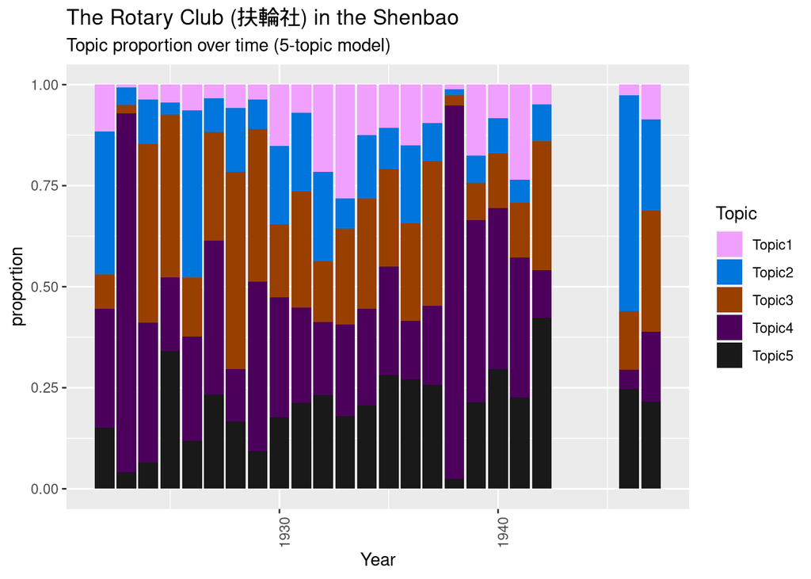

```r
require(pals)

# 5-topic model:
ggplot(vizDataFrame5y, aes(x=Year, y=value, fill=variable)) +
  geom_bar(stat = "identity") + ylab("proportion") +
  scale_fill_manual(values = paste0(alphabet(20), "FF"), name = "Topic") +
  theme(axis.text.x = element_text(angle = 90, hjust = 1)) +
  labs(title="The Rotary Club (扶輪社) in the Shenbao",
       subtitle = "Topic proportion over time (5-topic model)")
```

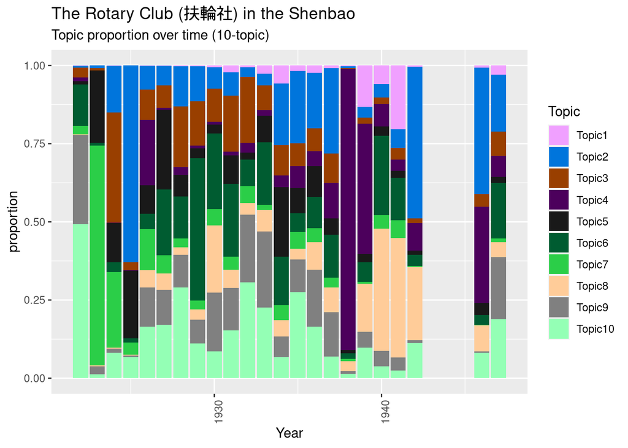

```r
# 10-topic model:
ggplot(vizDataFrame10y, aes(x=Year, y=value, fill=variable)) +
  geom_bar(stat = "identity") + ylab("proportion") +
  scale_fill_manual(values = paste0(alphabet(20), "FF"), name = "Topic") +
  theme(axis.text.x = element_text(angle = 90, hjust = 1)) +
  labs(title="The Rotary Club (扶輪社) in the Shenbao",
       subtitle = "Topic proportion over time (10-topic)")
```

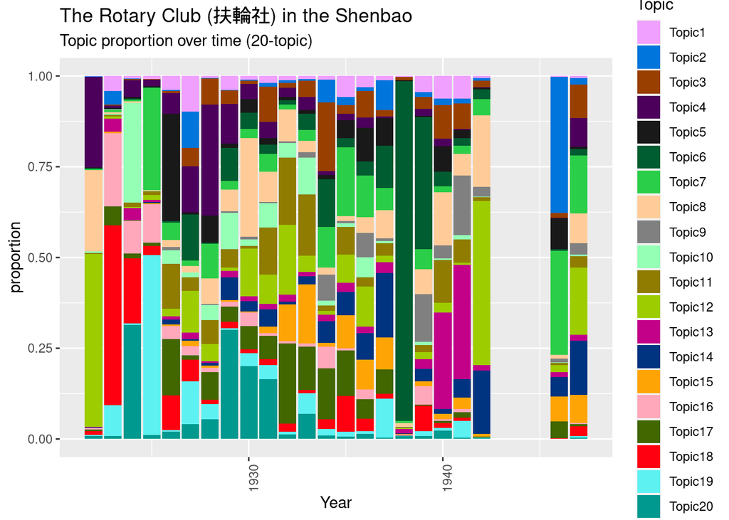

```r
# 20-topic model:
ggplot(vizDataFrame20y, aes(x=Year, y=value, fill=variable)) +
  geom_bar(stat = "identity") + ylab("proportion") +
  scale_fill_manual(values = paste0(alphabet(20), "FF"), name = "Topic") +
  theme(axis.text.x = element_text(angle = 90, hjust = 1))+
  labs(title="The Rotary Club (扶輪社) in the Shenbao",
       subtitle = "Topic proportion over time (20-topic)")
```

# Concluding remarks

Methodologically, the contribution of this paper is threefold:

1. First, it has offered a simple yet efficient solution, based on concordance, to the problem of article segmentation in digitized newspapers. This preliminary method needs to be refined and adjusted to different types of texts depending on their varying length and relevance to the research question.
2. Second, this paper constitutes a rare instance of cross-lingual comparison involving the Chinese language during its transitional stage between classical and modern Chinese. As a low-resource language, pre-modern Chinese presents significant challenges for the application of natural language processing tools and computer-assisted text analysis. As E. Kaske has demonstrated (Kaske, 2007), the Chinese language was highly unstable during the century under study, which was a pivotal phase in the creation of a standard vernacular (baihua) national language (guoyu). In his data-driven study of the *Shenbao*, P. Magistry has shown that the Chinese language actually evolved through six main stages between 1872 and 1949. Further research should pay greater attention to the decisions made during the pre-processing phase and design strict protocols for evaluating the impact of tokenization and language variation on the resulting topics. From a multilingual perspective, future research could also benefit from more sophisticated techniques for the automatic alignment of topics across languages. It could also investigate the differences between the various English periodicals included in the ProQuest collection, especially between the British North China Herald, the American China Weekly Review, and the Chinese-owned China Press.
3. Third, this research has demonstrated the value of combining different models with different k number of topics, instead of focusing on a single, definitive model. This multi-model approach is particularly appropriate when dealing with corpora of different sizes and with different structures. This multi-scalar reading of corpora enables scholars to navigate between different levels of granularity and to select in each model the topics that are the most relevant to the research question.

The results of this topic modeling exercise can be used as a starting point for addressing more specific research questions. The inferred topics point to the existence of two main categories of articles that can be further investigated using adequate methods. On the one hand, topics related to meetings, organization, and philanthropy are generally rich with names of individuals, organizations, and locations. Named entity recognition (NER) and network analysis can then be utilized to automatically extract the names of these actors and further analyze their connections. On the other hand, topics related to lectures and discussions (forums), which are richer in semantic contents, lend themselves to a deeper examination of the discourses articulated by the various actors, using methods such as semantic and sentiment analysis. Finally, while the Rotary Club has served as a test case in this paper, our methodology can be expanded to investigate other public sphere institutions and more abstract concepts related to the public sphere. Furthermore, it can be transposed to similar digitized texts in English, Chinese, and possibly other languages, beyond the specific corpora utilized in this research.

# References

Armand, Cécile. “Foreign Clubs with Chinese Flavor: The Rotary Club of Shanghai and the Politics of Language.” In Knowledge, Power, and Networks: Elites in Transition in Modern China, edited by Cécile Armand, Christian Henriot, and Huei-min Sun, 233–59. Leiden: Brill, 2022. Huang, Philip C.C. “‘Public Sphere “/”Civil Society’ in China? The Third Realm between State and Society.” Modern China Modern China 19, no. 2 (1993): 216–40. Kaske, Elisabeth. The Politics of Language in Chinese Education, 1895-1919. Vol. 82. Sinica Leidensia. Leiden: Brill, 2007. Magistry, Pierre. “Languages(s) of the Shun-Pao, a Computational Linguistics Account.” In 10th International Conference of Digital Archives and Digital Humanities. Taipei, Taiwan, 2019. Rankin, Mary Backus. “The Origins of a Chinese Public Sphere. Local Elites and Community Affairs in the Late Imperial Period.” Études Chinoises 9, no. 2 (1990): 13–60. Wagner, Rudolf G, ed. Joining the Global Public: Word, Image, and City in Early Chinese Newspapers, 1870-1910. Albany, NY: State University of New York Press, 2007. Wakeman, Frederic. “The Civil Society and Public Sphere Debate: Western Reflections on Chinese Political Culture.” Modern China 19, no. 2 (1993): 108–38.

# Acknowledgements

This research has received funding from the European Research Council (ERC) under the European Union’s Horizon 2020 research and innovation programme (grant agreement No 788476) and a CCFK grant.

[^1]: *Shenbao* was a leading newspaper published in Shanghai between 1872 and 1949. Despite low literacy rates among the Chinese population, it reached 150,000 copies in the 1930s, making one of the two most widely circulated newspapers in China. Although it catered primarily to Shanghai intellectual, political, and business elites, its readership widened in the 1930s. Although it was printed in Shanghai, *Shenbao* had a national, even international coverage, being also circulated among overseas Chinese
[^2]: Margaret Roberts et al., “Stm: Estimation of the Structural Topic Model,” September 18, 2020, 64–65, https://CRAN.R-project.org/package=stm